# Mechanisms Underlying Intergroup Conflict

## Briefly from Last Week:

Laurence found that people living in diverse and segregated areas had rather negative attitudes towards immigrants, while people who lived in diverse and integrated areas had positive attitudes.

But what do these areas look like?

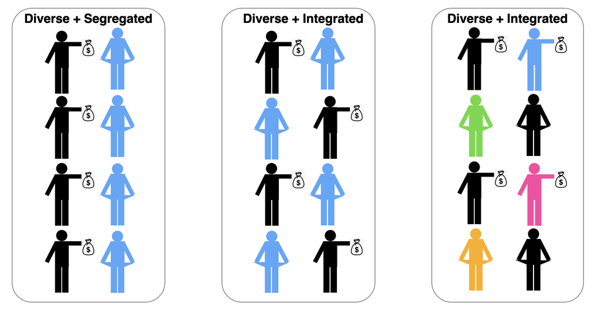

Basic takeaway: in order to interpret our results, we need to know exactly what we are measuring!

## Learning Goals:

1. Define a **mechanism** in the parlance of social scientists
2. Describe the **economic** and **cultural threats** underlying conflict theory, in both their **egocentric** and **sociotropic** versions
3. Describe the concept of a **compound treatment**, and explain how it can complicate our efforts to draw inferences from data.
4. Contrast conflict theory and **Social Identity Theory**’s explanations for how group biases arise.

## Introduction

So far, we have examined evidence demonstrating that increasing diversity leads to anti-minority attitudes and behaviors. But **why** does this relationship exist? A **mechanism** tell us “why”.

**Example**

Consider Durkheim’s classic study of suicide, summarized from *The Practice of Social Research* by Earl Babbie, pp.339-340.

Durkheim noticed two empirical patterns in suicide rates:

- Although suicide rates were generally stable from year to year, they also tended to spike during periods of political upheaval / revolutions.
- Suicide rates were consistently higher in Protestant areas of Europe, compared to Catholic areas.

Durkheim thought there was a single mechanism linking these two patterns. In particular, he suggested that many suicides are a product of *anomie* or “normlessness”, or a general sense of social instability and disintegration. During times of political unrest, people feel that the old ways of society are collapsing, and suicide is one answer to this severe discomfort. In contrast, social integration and solidarity offer protection against suicide. And Catholicism, as a more structured and integrated religious system, gave people a greater sense of coherence and stability.

In this story, feelings of *anomie* are the mechanism which explains the internal logic behind the broader empirical patterns we observe.

Note however that Durkheim never **directly** tested this mechanism. That’s what we’ll talk about over the next 2 weeks.

## Economic and Cultural Threats

We know from Enos (and other experimental work) that exposure to immigration can cause whites to adopt anti-immigration attitudes. One influential set of mechanisms focuses on feelings of threat induced by immigration.

Your readings mentioned several different types of threats related to the **economic** and **cultural** impacts of immigration, as well as concerns about **security** and **safety**.

Social scientists also often talk about **egocentric** vs **sociotropic** concerns over immigration.

- Egocentric concerns are self-interested. That is, an individual opposes immigration because it has adverse consequences for her, personally.
- Sociotropic concerns relate to the impact of immigration for the larger nation / society. Under these accounts, an individual may personally benefit for immigration, but still oppose it if he believes that it’s bad for the country as a whole.

**Small groups:** in which cells of the table would you place the following statements:

1. “If you come here because you heard our welfare system is great, and you get really great healthcare too, then no, get your butt back to where you came from.”
2. “They’re bringing drugs. They’re bringing crime. They’re rapists. And some, I assume, are good people.”
3. “They’re taking our jobs!”
4. “At this shop, most of the workers speak Turkish, even though this is the Netherlands and this is a Dutch shop. I hate it that they speak Turkish every time that I am there. It’s rude and arrogant, and makes me feel like I’m important, like I’m not even there.”
5. “Dutch children feel threatened, my daughter feels herself to be threatened in a group of those immigrant children…my daughter will hit back when it is one other child but not when they are four or five. Just see what happens when you disagree with an immigrant and it gets a little out of hand, then there immediately show up five or ten around you and you will have no chance.”
6. “One thing that really bothers me is the fact that immigrants have their own TV and radio stations. They practically have the ability to live in a separate, self-contained society, separate from our own society, yet within our borders because they have their own media, their own stores, their own communities and so on within the midst of our communities.”

| A Typology of Threats: Reasons Why Natives May Dislike Immigrants | A Typology of Threats: Reasons Why Natives May Dislike Immigrants Egocentric | A Typology of Threats: Reasons Why Natives May Dislike Immigrants Sociotropic |
| --- | --- | --- |
| Economic Threat | ? | ? |
| Cultural Threat | ? | ? |
| Safety Threat | ? | ? |

### A Problem of Evidence

Here’s a thought experiment from *When Ways of Life Collide* pp.80-81:

*You join two neighbors in the middle of a conversation. One confides in you. Taking in immigrant minorities has provided a pool of cheap labor; already it has cost some of her friends their jobs; now she fears it threatens hers. The second neighbor joins in, agreeing that immigrants threaten a lot of people’s jobs and, what is more, immigrants suck up government assistance, costing Dutch society more and more each year, and have driven up the crime rate.*

*You have known both neighbors for a long time. Previously the first neighbor did not complain about immigrants — indeed, she had expressed some sympathy toward them and their problems. The second has complained about immigrant minorities for as long as you have known him…In fact, he has always disliked almost everything about minorities — their talking a foreign language in public, their offensive behavior, the odd clothes they wear, and so on and so forth.*

*Both neighbors are critical of immigrant minorities. But they differ in a key respect. One perceives that immigrants pose an economic threat; the other dislikes them pure and simple.*

Imagine researchers conduct a survey where they ask two questions:

1. Do you believe that immigrants threaten jobs for “native” Dutch?
2. Do you believe that the Netherlands should restrict immigration?

They find a strong correlation: people who answer that immigrants threaten “native” jobs are also much more likely to support immigration restrictions.

**Discussion:** Would you take this as evidence in favor of the economic threat mechanism?

## A Template for Survey Experiments

Suppose you wanted to test the mechanism that cultural threat drives attitudes towards refugees. Your hypothesis is that refugees from majority-Muslim countries (e.g. Syria) are perceived as more culturally threatening – and are thus more disfavored – than refugees from majority-Christian countries (e.g. Ukraine).

You recruit a representative sample of native Germans to participate in a survey. You randomly divide survey respondents into two groups.

Both groups receive the following prompt:

“Imagine you live in a small town of around 1000 people. Last year, because of reduced tourism due to the COVID pandemic, your town’s hotel was forced to close. Recently, you learn that the empty hotel building will be converted into refugee accommodation for 30 asylum seekers from _____.”

For group A _____ is filled in with **Syria**, while for group B _____is filled in with **Ukraine**.

Respondents in both groups are then asked how much they support or oppose the hotel conversion.

**Discussion:** By comparing the average reponses of group A vs B, do you think you have isolated the effect of cultural threat on attitudes towards refugees?

**Compound Treatments:**

Here, the problem is that Ukrainian and Syrian refugees differ not only on the religious dimension, but also on dimensions such as gender or education. So we have what is called a **compound treatment**. In this case, while we have identified a treatment effect, we don’t know what element of the compound treatment is “doing the work.”

**Towards a solution:**

“Imagine you live in a small town of around 1000 people. Last year, because of reduced tourism due to the COVID pandemic, your town’s hotel was forced to close. Recently, you learn that the empty hotel building will be converted into refugee accommodation for 30 asylum seekers from _____. You have further been informed that the refugees will all be women and children who are fleeing violence in their home countries. These refugees have already been in Germany for several months, and have learned basic German skills through prior participation in organized integration courses.”

**Small Groups**

Your task is to design a scientific study which would test one or more of the mechanisms we discussed. Imagine you had the opportunity to add a survey experiment to an existing high-quality representative survey in Germany. Please discuss:

- What is the specific mechanism you hope to test via your study?
- What is your hypothesis?
- What specific experimental prompt would you use?

Write up your experimental prompt in [Padlet](https://padlet.com/nzhang23/fo61vkoin8fshg2z) and be prepared to present it to the class.

## Social Identity Theory

The above mechanisms posit that prejudices arise from group conflicts over economic and symbolic (cultural) resources.

But what if the simple act of categorizing people into groups gives rise to bias and in-group favoritism?

This is the main insight of **Social Identity Theory.**

Of course, real-life groups come with a lot of “baggage” – tradition, shared experience, socialization, common institutions, etc. The trick is in demonstrating the causal effect of categorization, free from all of this baggage. This was done through experiments using the **minimum group paradigm**.

### Allocation to Groups

How many dots are in the this image?

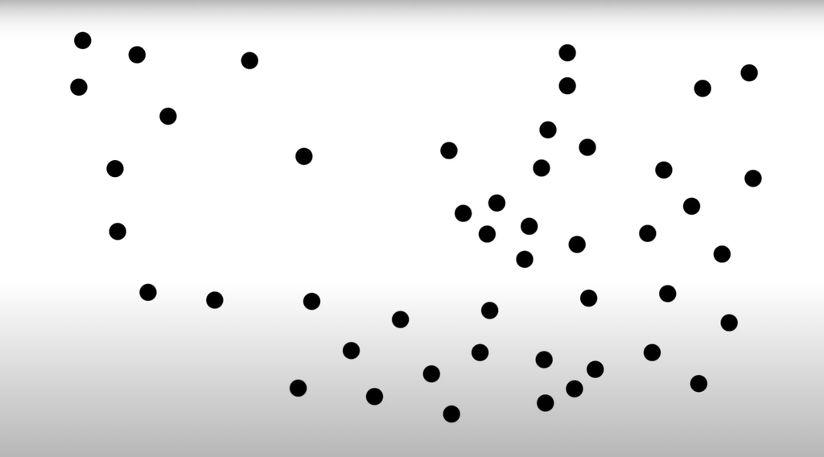

Experimental participants are then divided into “overcounters” and “undercounters”.

### Measuring Group Bias

Which allocation would you prefer?

- **Option A**: 8 EUR for the ingroup and 6 EUR for the outgroup
- **Option B**: 6 EUR for the ingroup and 1 EUR for the outgroup

Notice that Option A maximizes absolute gains for the ingroup, but minimizes the ingroup-outgroup “gap”. Alternatively, picking Option B makes your group *relatively* better off, but *absolutely* worse off.

Another way of thinking about this: if you pick Option B, you are paying a cost to harm the outgroup.

### Food for thought:

If the mere act of categorization leads to bias, what do you think about the following prejudice-reduction strategies?

- Celebrate diversity by playing up the unique contributions of different ethnic groups to a multicultural society
- Encouraging others to “not see color”, but rather to treat everyone as individuals
- Emphasizing a common citizenship that supercedes racial, religious and ethnic differences

Implications of Conflict Theory vs. SIT for intergroup relations:

- Under Conflict Theory, we might think about reducing real or perceived competition between groups in order to improve group relations
- Under SIT, we might instead think about the reducing the salience of group boundaries and emphasizing instead an overarching basis of identity